# R_TUTORIAL_DESCRIPTIVES

# 6. interactions with continuous x continous variables

These can be fun but also tricky in R. First, let’s visualize how two continuous variables might interact. We will use the coplot() function where: y ~ x | m

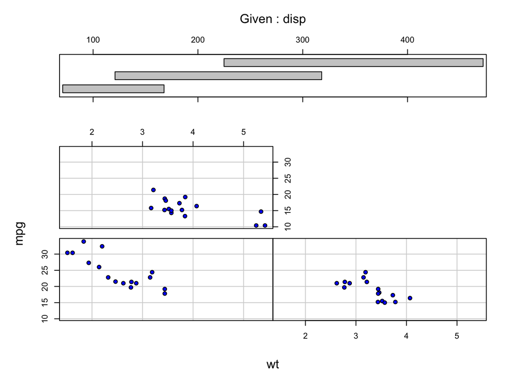

```r
coplot(mpg ~ wt | disp, data = mtcars,number = 3,
       col = "black", bg = "blue", pch = 21)
```

Next, let’s run the linear model using lm (). The * indicates an interaction, where R will include the individual coefficienets for each variable automatically.

```r
model4 <- lm(mpg ~ wt* disp, data = mtcars )
summary(model4)
```

```
##
## Call:
## lm(formula = mpg ~ wt * disp, data = mtcars)
##
## Residuals:
##    Min     1Q Median     3Q    Max
## -3.267 -1.677 -0.836  1.351  5.017
##
## Coefficients:
##              Estimate Std. Error t value Pr(>|t|)
## (Intercept) 44.081998   3.123063  14.115 2.96e-14 ***
## wt          -6.495680   1.313383  -4.946 3.22e-05 ***
## disp        -0.056358   0.013239  -4.257  0.00021 ***
## wt:disp      0.011705   0.003255   3.596  0.00123 **
## ---
## Signif. codes:  0 '***' 0.001 '**' 0.01 '*' 0.05 '.' 0.1 ' ' 1
##
## Residual standard error: 2.455 on 28 degrees of freedom
## Multiple R-squared:  0.8501, Adjusted R-squared:  0.8341
## F-statistic: 52.95 on 3 and 28 DF,  p-value: 1.158e-11
```

The effect plot automatically choses specific levels of the variables to display your interactions.

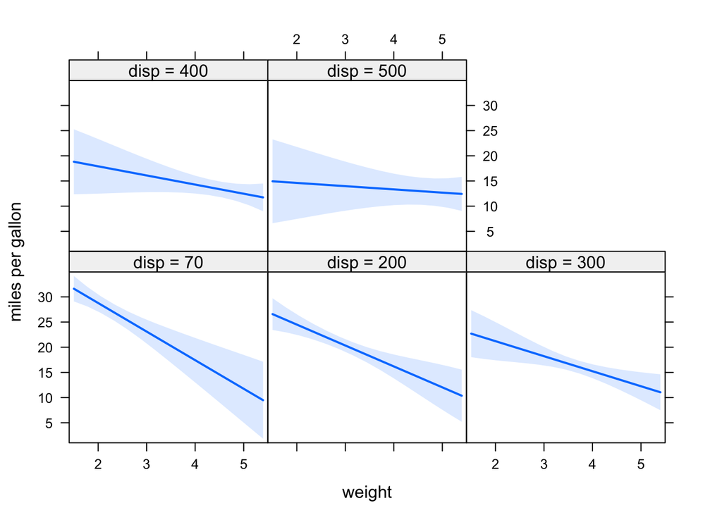

```r
plot(effect("wt:disp", model4), rug = F, main = "", ylab= "miles per gallon", xlab = "weight")
```

You can also just plot the linesin a single plot (without CI) using the multiline=T option.

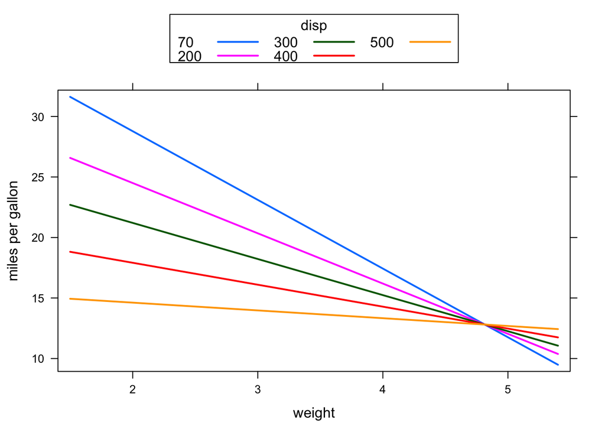

```r
plot(effect("wt:disp", model4), multiline=T, rug = F, main = "", ylab= "miles per gallon", xlab = "weight")
```

# 7. more on model visualizations:

what about viewing the actual fitted data points (instead of the regression lines) ? Added Variable plots (or partial regression plot) allow us to look at the fitted data of our variable of interest, controlling for all of the other stuff in your model.

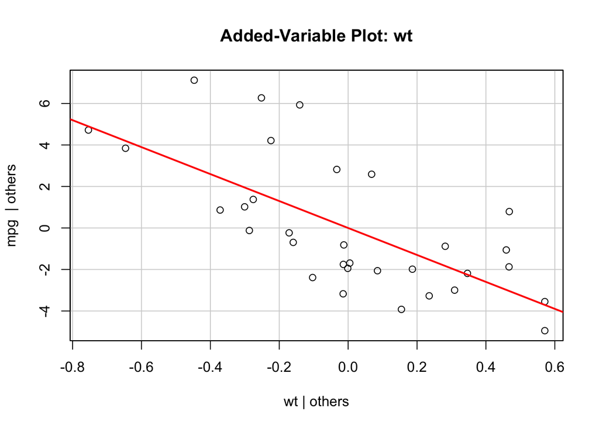

```r
avPlot(model4, "wt")
```

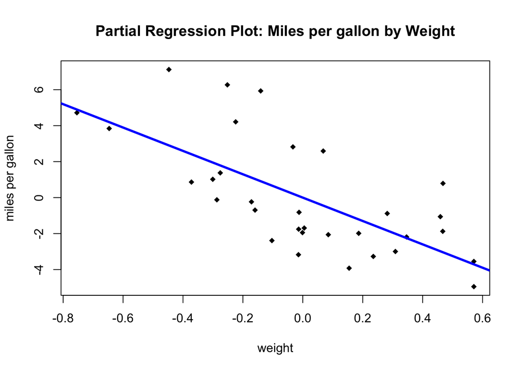

```r
# make it prettier!
avPlot(model4, "wt", col = "Black", col.lines = "Blue", pch = 18, lwd= 3,
       ylab = "miles per gallon",
       xlab ="weight", grid = FALSE,
       main = "Partial Regression Plot: Miles per gallon by Weight")
```

if you want to really make beautiful graphs and customizations of your models, we encourage you to experiment with ggplot!

This was only a brief introduction to the statistical modeling world of R. There are many more options available: mixed-effects modeling, mediations, structural equation models, bayesian estimation.

# Data Challenge:

Now it’s your turn! There are two data setsfor this challenge. One is data from a single subjects task performance across all trials (repeated measures). The second dataset consists of summary data from each subject on this task (between subjects).

```r
#1. Perform a paired-samples t-test to determine whether subject 001 is more accurate when matching faces or shapes.

#2. Perform a t-test to determine whether there are group differences in Accuracy.

#3. perform a linear regression to test the effects of age on accuracy.
```

# Bonus Data Challenge

Design your own research question from this data and use the appropriate test to analyze it. Use ggplot to plot the raw data & the fitted results of your model.